# 9 – Additional Analysis: Partner Emotion Word Use as Predictor of Child Emotion Word Use

# Overview

**Research question** — If social partners talk more about emotion, do children talk more about emotion too? And does this association change across development?

This analysis operates at the **transcript level** (one observation per transcript), complementing the turn-by-turn CRQA approach in script 09.

**Part 2 — Partner-type comparison**: Restricted to transcripts where the child speaks to exactly one partner type. Tests whether the partner → child association differs by who the child is talking to (Mother, Father, Sibling, etc.).

## 0. Setup

```r
source(here::here("00_setup.R"))
library(lme4)
library(lmerTest)
library(splines)
library(emmeans)
library(mediation)
library(broom.mixed)
library(ggeffects)
```

## 1. Load data

```r
utt <- readRDS(here("01Data", "02Derived", "FINAL_utt_RQ1_emotions_merged.rds"))

cat("Rows:        ", nrow(utt), "\n")
```

```
## Rows:         3078100
```

```r
cat("Transcripts: ", n_distinct(utt$transcript_id), "\n")
```

```
## Transcripts:  7117
```

```r
cat("Children:    ", n_distinct(utt$target_child_id), "\n")
```

```
## Children:     1062
```

## 2. Build transcript-level age lookup

`target_child_age` is only populated on child-speaker rows in CHILDES. Build a reliable transcript-level lookup from child utterances only.

```r
age_lookup <- utt %>%
  filter(role_category == "Target Child", !is.na(target_child_age)) %>%
  group_by(transcript_id) %>%
  summarise(
    target_child_age = first(target_child_age),
    target_child_sex = first(target_child_sex),
    target_child_id  = first(target_child_id),
    .groups = "drop"
  )
```

# PART 1 — Full Sample (all partner types collapsed)

## 3. Aggregate all transcripts — partner as single category

All non-child utterances are summed into one “partner” series per transcript, regardless of who is speaking.

```r
speaker_summary_all <- utt %>%
  mutate(speaker_category = if_else(role_category == "Target Child",
                                    "child", "partner")) %>%
  group_by(transcript_id, speaker_category) %>%
  summarise(
    total_tokens  = sum(num_tokens,    na.rm = TRUE),
    total_emotion = sum(emotion_count, na.rm = TRUE),
    n_utterances  = n(),
    .groups = "drop"
  ) %>%
  mutate(emo_rate = if_else(total_tokens > 0,
                             total_emotion / total_tokens, NA_real_))

transcript_all <- speaker_summary_all %>%
  pivot_wider(
    id_cols     = transcript_id,
    names_from  = speaker_category,
    values_from = c(emo_rate, total_tokens, total_emotion, n_utterances)
  ) %>%
  rename(
    child_emo_rate   = emo_rate_child,
    partner_emo_rate = emo_rate_partner,
    child_tokens     = total_tokens_child,
    partner_tokens   = total_tokens_partner,
    child_emotion    = total_emotion_child,
    partner_emotion  = total_emotion_partner,
    child_utts       = n_utterances_child,
    partner_utts     = n_utterances_partner
  ) %>%
  left_join(age_lookup, by = "transcript_id") %>%
  mutate(target_child_age_yrs = target_child_age / 12) %>%
  filter(
    !is.na(child_emo_rate),
    !is.na(partner_emo_rate),
    !is.na(target_child_age_yrs),
    child_tokens   >= 10,
    partner_tokens >= 10
  )

cat("Transcripts (full sample):", nrow(transcript_all), "\n")
```

```
## Transcripts (full sample): 5614
```

```r
cat("Children:                 ", n_distinct(transcript_all$target_child_id), "\n")
```

```
## Children:                  871
```

```r
cat("Age range:                ", round(min(transcript_all$target_child_age_yrs), 2),
    "–", round(max(transcript_all$target_child_age_yrs), 2), "years\n")
```

```
## Age range:                 0.5 – 12.04 years
```

## 4. Descriptives — full sample

```r
transcript_all %>%
  summarise(
    n_transcripts    = n(),
    n_children       = n_distinct(target_child_id),
    age_min          = round(min(target_child_age_yrs),  2),
    age_max          = round(max(target_child_age_yrs),  2),
    child_emo_mean   = round(mean(child_emo_rate),       4),
    child_emo_sd     = round(sd(child_emo_rate),         4),
    partner_emo_mean = round(mean(partner_emo_rate),     4),
    partner_emo_sd   = round(sd(partner_emo_rate),       4)
  ) %>% print()
```

```
## # A tibble: 1 × 8
##   n_transcripts n_children age_min age_max child_emo_mean child_emo_sd
##           <int>      <int>   <dbl>   <dbl>          <dbl>        <dbl>
## 1          5614        871     0.5    12.0         0.0149       0.0196
## # ℹ 2 more variables: partner_emo_mean <dbl>, partner_emo_sd <dbl>
```

```r
cor.test(transcript_all$child_emo_rate, transcript_all$partner_emo_rate)
```

```
##
##  Pearson's product-moment correlation
##
## data:  transcript_all$child_emo_rate and transcript_all$partner_emo_rate
## t = 25.221, df = 5612, p-value < 2.2e-16
## alternative hypothesis: true correlation is not equal to 0
## 95 percent confidence interval:
##  0.2953828 0.3423785
## sample estimates:
##       cor
## 0.3190768
```

## 5. Within-child / between-child decomposition

```r
transcript_all <- transcript_all %>%
  group_by(target_child_id) %>%
  mutate(
    partner_emo_between = mean(partner_emo_rate, na.rm = TRUE),
    partner_emo_within  = partner_emo_rate - partner_emo_between
  ) %>%
  ungroup()
```

## 6. Moderation — does age moderate the partner → child association?

### 6a. Fit model

```r
m_mod <- lmer(
  child_emo_rate ~
    partner_emo_within  * ns(target_child_age_yrs, df = 3) +
    partner_emo_between * ns(target_child_age_yrs, df = 3) +
    target_child_sex +
    (1 + partner_emo_within | target_child_id),
  data    = transcript_all,
  REML    = TRUE,
  control = lmerControl(optimizer = "bobyqa")
)

summary(m_mod)
```

```
## Linear mixed model fit by REML. t-tests use Satterthwaite's method [
## lmerModLmerTest]
## Formula: child_emo_rate ~ partner_emo_within * ns(target_child_age_yrs,
##     df = 3) + partner_emo_between * ns(target_child_age_yrs,
##     df = 3) + target_child_sex + (1 + partner_emo_within | target_child_id)
##    Data: transcript_all
## Control: lmerControl(optimizer = "bobyqa")
##
## REML criterion at convergence: -28698.7
##
## Scaled residuals:
##     Min      1Q  Median      3Q     Max
## -3.8143 -0.4396 -0.1347  0.2398 12.7740
##
## Random effects:
##  Groups          Name               Variance  Std.Dev. Corr
##  target_child_id (Intercept)        5.725e-05 0.007567
##                  partner_emo_within 1.025e-01 0.320155 0.58
##  Residual                           2.595e-04 0.016109
## Number of obs: 5380, groups:  target_child_id, 853
##
## Fixed effects:
##                                                         Estimate Std. Error
## (Intercept)                                            2.954e-04  3.615e-03
## partner_emo_within                                     5.695e-01  1.121e-01
## ns(target_child_age_yrs, df = 3)1                      1.479e-02  4.465e-03
## ns(target_child_age_yrs, df = 3)2                     -3.028e-03  8.312e-03
## ns(target_child_age_yrs, df = 3)3                     -7.650e-03  6.666e-03
## partner_emo_between                                   -1.673e-01  1.600e-01
## target_child_sexmale                                  -2.375e-05  9.622e-04
## partner_emo_within:ns(target_child_age_yrs, df = 3)1  -5.698e-01  1.625e-01
## partner_emo_within:ns(target_child_age_yrs, df = 3)2  -2.709e-01  2.441e-01
## partner_emo_within:ns(target_child_age_yrs, df = 3)3   2.774e-01  2.081e-01
## ns(target_child_age_yrs, df = 3)1:partner_emo_between -1.168e+00  2.587e-01
## ns(target_child_age_yrs, df = 3)2:partner_emo_between  2.207e+00  3.860e-01
## ns(target_child_age_yrs, df = 3)3:partner_emo_between  1.573e+00  3.829e-01
##                                                               df t value
## (Intercept)                                            1.548e+03   0.082
## partner_emo_within                                     7.837e+02   5.080
## ns(target_child_age_yrs, df = 3)1                      7.653e+02   3.312
```

[output cut: 11 more lines]

```
## (Intercept)                                           0.934877
## partner_emo_within                                    4.71e-07 ***
## ns(target_child_age_yrs, df = 3)1                     0.000968 ***
## ns(target_child_age_yrs, df = 3)2                     0.715730
## ns(target_child_age_yrs, df = 3)3                     0.251475
## partner_emo_between                                   0.296123
## target_child_sexmale                                  0.980324
## partner_emo_within:ns(target_child_age_yrs, df = 3)1  0.000478 ***
## partner_emo_within:ns(target_child_age_yrs, df = 3)2  0.267197
## partner_emo_within:ns(target_child_age_yrs, df = 3)3  0.182642
## ns(target_child_age_yrs, df = 3)1:partner_emo_between 6.99e-06 ***
## ns(target_child_age_yrs, df = 3)2:partner_emo_between 1.33e-08 ***
## ns(target_child_age_yrs, df = 3)3:partner_emo_between 4.33e-05 ***
## ---
## Signif. codes:  0 '***' 0.001 '**' 0.01 '*' 0.05 '.' 0.1 ' ' 1
```

```
##
## Correlation matrix not shown by default, as p = 13 > 12.
## Use print(x, correlation=TRUE)  or
##     vcov(x)        if you need it
```

### 6b. Test within × age interaction

```r
m_mod_noint <- lmer(
  child_emo_rate ~
    partner_emo_within +
    partner_emo_between * ns(target_child_age_yrs, df = 3) +
    target_child_sex +
    (1 + partner_emo_within | target_child_id),
  data    = transcript_all,
  REML    = FALSE,
  control = lmerControl(optimizer = "bobyqa")
)

anova(m_mod_noint, update(m_mod, REML = FALSE))
```

```
## Data: transcript_all
## Models:
## m_mod_noint: child_emo_rate ~ partner_emo_within + partner_emo_between * ns(target_child_age_yrs, df = 3) + target_child_sex + (1 + partner_emo_within | target_child_id)
## update(m_mod, REML = FALSE): child_emo_rate ~ partner_emo_within * ns(target_child_age_yrs, df = 3) + partner_emo_between * ns(target_child_age_yrs, df = 3) + target_child_sex + (1 + partner_emo_within | target_child_id)
##                             npar    AIC    BIC logLik -2*log(L)  Chisq Df
## m_mod_noint                   14 -28724 -28632  14376    -28752
## update(m_mod, REML = FALSE)   17 -28737 -28625  14386    -28771 18.662  3
##                             Pr(>Chisq)
## m_mod_noint
## update(m_mod, REML = FALSE)  0.0003212 ***
## ---
## Signif. codes:  0 '***' 0.001 '**' 0.01 '*' 0.05 '.' 0.1 ' ' 1
```

### 6c. Simple slopes — partner effect at each age

```r
emtrends(m_mod,
         var   = "partner_emo_within",
         specs = ~ target_child_age_yrs,
         at    = list(target_child_age_yrs = c(2, 4, 6, 8, 10)))
```

```
## Note: D.f. calculations have been disabled because the number of observations exceeds 3000.
## To enable adjustments, add the argument 'pbkrtest.limit = 5380' (or larger)
## [or, globally, 'set emm_options(pbkrtest.limit = 5380)' or larger];
## but be warned that this may result in large computation time and memory use.
```

```
## Note: D.f. calculations have been disabled because the number of observations exceeds 3000.
## To enable adjustments, add the argument 'lmerTest.limit = 5380' (or larger)
## [or, globally, 'set emm_options(lmerTest.limit = 5380)' or larger];
## but be warned that this may result in large computation time and memory use.
```

```
##  target_child_age_yrs partner_emo_within.trend     SE  df asymp.LCL asymp.UCL
##                     2                    0.457 0.0556 Inf   0.34783     0.566
##                     4                    0.253 0.0610 Inf   0.13328     0.373
##                     6                    0.183 0.0920 Inf   0.00259     0.363
##                     8                    0.286 0.0994 Inf   0.09087     0.481
##                    10                    0.504 0.1290 Inf   0.25182     0.757
##
## Results are averaged over the levels of: target_child_sex
## Degrees-of-freedom method: asymptotic
## Confidence level used: 0.95
```

### 6d. Moderation plot

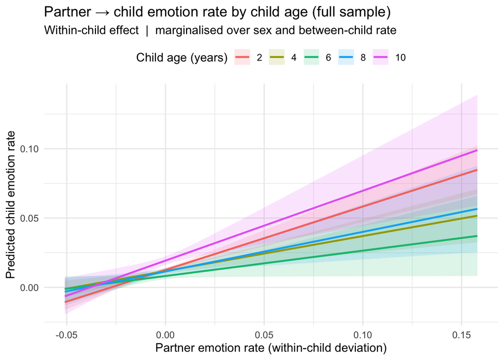

```r
pred_mod <- ggpredict(
  m_mod,
  terms = c("partner_emo_within [all]", "target_child_age_yrs [2, 4, 6, 8, 10]")
)

ggplot(pred_mod, aes(x = x, y = predicted,
                     colour = group, fill = group)) +
  geom_ribbon(aes(ymin = conf.low, ymax = conf.high),
              alpha = 0.15, colour = NA) +
  geom_line(linewidth = 0.9) +
  labs(
    title    = "Partner → child emotion rate by child age (full sample)",
    subtitle = "Within-child effect  |  marginalised over sex and between-child rate",
    x        = "Partner emotion rate (within-child deviation)",
    y        = "Predicted child emotion rate",
    colour   = "Child age (years)", fill = "Child age (years)"
  ) +
  theme_minimal(base_size = 12) +
  theme(legend.position = "top")
```

## 7. Mediation — does partner rate explain the age effect on child rate?

**Causal chain**: Age → partner_emo_rate → child_emo_rate

### 7a. Path a: age → partner rate

```r
m_med_a <- lmer(
  partner_emo_rate ~
    ns(target_child_age_yrs, df = 3) +
    target_child_sex +
    (1 | target_child_id),
  data = transcript_all,
  REML = TRUE
)
summary(m_med_a)
```

```
## Linear mixed model fit by REML. t-tests use Satterthwaite's method [
## lmerModLmerTest]
## Formula:
## partner_emo_rate ~ ns(target_child_age_yrs, df = 3) + target_child_sex +
##     (1 | target_child_id)
##    Data: transcript_all
##
## REML criterion at convergence: -29840.9
##
## Scaled residuals:
##     Min      1Q  Median      3Q     Max
## -2.9635 -0.4473 -0.1025  0.2855 10.6360
##
## Random effects:
##  Groups          Name        Variance  Std.Dev.
##  target_child_id (Intercept) 1.928e-05 0.004391
##  Residual                    2.187e-04 0.014789
## Number of obs: 5380, groups:  target_child_id, 853
##
## Fixed effects:
##                                     Estimate Std. Error         df t value
## (Intercept)                        1.885e-02  1.077e-03  2.557e+03  17.504
## ns(target_child_age_yrs, df = 3)1 -8.999e-03  1.451e-03  3.168e+03  -6.200
## ns(target_child_age_yrs, df = 3)2 -2.598e-03  2.493e-03  2.785e+03  -1.042
## ns(target_child_age_yrs, df = 3)3 -1.349e-03  1.976e-03  4.630e+03  -0.682
## target_child_sexmale               5.213e-04  7.652e-04  7.565e+02   0.681
##                                   Pr(>|t|)
## (Intercept)                        < 2e-16 ***
## ns(target_child_age_yrs, df = 3)1 6.36e-10 ***
## ns(target_child_age_yrs, df = 3)2    0.298
## ns(target_child_age_yrs, df = 3)3    0.495
## target_child_sexmale                 0.496
## ---
## Signif. codes:  0 '***' 0.001 '**' 0.01 '*' 0.05 '.' 0.1 ' ' 1
##
## Correlation of Fixed Effects:
##             (Intr) n(___,d=3)1 n(___,d=3)2 n(___,d=3)3
## n(___,d=3)1 -0.094
## n(___,d=3)2 -0.822  0.041
## n(___,d=3)3 -0.323 -0.258       0.643
## trgt_chld_s -0.327 -0.019      -0.021       0.010
```

### 7b. Path b: partner rate → child rate (controlling age)

```r
m_med_b <- lmer(
  child_emo_rate ~
    partner_emo_rate +
    ns(target_child_age_yrs, df = 3) +
    target_child_sex +
    (1 | target_child_id),
  data = transcript_all,
  REML = TRUE
)
summary(m_med_b)
```

```
## Linear mixed model fit by REML. t-tests use Satterthwaite's method [
## lmerModLmerTest]
## Formula: child_emo_rate ~ partner_emo_rate + ns(target_child_age_yrs,
##     df = 3) + target_child_sex + (1 | target_child_id)
##    Data: transcript_all
##
## REML criterion at convergence: -28472.3
##
## Scaled residuals:
##     Min      1Q  Median      3Q     Max
## -4.7068 -0.4788 -0.1429  0.2368 13.0254
##
## Random effects:
##  Groups          Name        Variance  Std.Dev.
##  target_child_id (Intercept) 5.963e-05 0.007722
##  Residual                    2.734e-04 0.016535
## Number of obs: 5380, groups:  target_child_id, 853
##
## Fixed effects:
##                                     Estimate Std. Error         df t value
## (Intercept)                       -1.033e-02  1.334e-03  1.279e+03  -7.746
## partner_emo_rate                   3.440e-01  1.544e-02  5.216e+03  22.287
## ns(target_child_age_yrs, df = 3)1 -4.467e-03  1.728e-03  2.219e+03  -2.585
## ns(target_child_age_yrs, df = 3)2  4.115e-02  2.993e-03  1.511e+03  13.747
## ns(target_child_age_yrs, df = 3)3  2.034e-02  2.301e-03  3.425e+03   8.840
## target_child_sexmale               8.148e-05  9.982e-04  3.264e+02   0.082
##                                   Pr(>|t|)
## (Intercept)                       1.92e-14 ***
## partner_emo_rate                   < 2e-16 ***
## ns(target_child_age_yrs, df = 3)1   0.0098 **
## ns(target_child_age_yrs, df = 3)2  < 2e-16 ***
## ns(target_child_age_yrs, df = 3)3  < 2e-16 ***
## target_child_sexmale                0.9350
## ---
## Signif. codes:  0 '***' 0.001 '**' 0.01 '*' 0.05 '.' 0.1 ' ' 1
##
## Correlation of Fixed Effects:
##             (Intr) prtn__ n(___,d=3)1 n(___,d=3)2 n(___,d=3)3
## partnr_m_rt -0.218
## n(___,d=3)1 -0.115  0.068
## n(___,d=3)2 -0.785  0.008  0.072
## n(___,d=3)3 -0.319  0.004 -0.221       0.644
## trgt_chld_s -0.338 -0.009 -0.029      -0.031       0.003
```

### 7c. Bootstrap indirect effect

```r
med_data <- transcript_all %>%
  filter(!is.na(target_child_age_yrs), !is.na(partner_emo_rate),
         !is.na(child_emo_rate), !is.na(target_child_sex))

m_med_a_lm <- lm(partner_emo_rate ~ target_child_age_yrs + target_child_sex,
                  data = med_data)

m_med_b_lm <- lm(child_emo_rate ~ partner_emo_rate + target_child_age_yrs +
                    target_child_sex, data = med_data)

set.seed(42)
med_out <- mediate(
  model.m  = m_med_a_lm,
  model.y  = m_med_b_lm,
  treat    = "target_child_age_yrs",
  mediator = "partner_emo_rate",
  boot     = TRUE,
  sims     = 1000
)
```

```
## Running nonparametric bootstrap
```

```r
summary(med_out)
```

```
##
## Causal Mediation Analysis
##
## Nonparametric Bootstrap Confidence Intervals with the Percentile Method
##
##                   Estimate 95% CI Lower 95% CI Upper p-value
## ACME           -4.0688e-04  -5.1364e-04  -3.1218e-04  <2e-16 ***
## ADE             5.3866e-04   3.0587e-04   7.8058e-04  <2e-16 ***
## Total Effect    1.3178e-04  -1.0666e-04   3.9250e-04   0.308
## Prop. Mediated -3.0876e+00  -3.3475e+01   2.9647e+01   0.308
## ---
## Signif. codes:  0 '***' 0.001 '**' 0.01 '*' 0.05 '.' 0.1 ' ' 1
##
## Sample Size Used: 5380
##
##
## Simulations: 1000
```

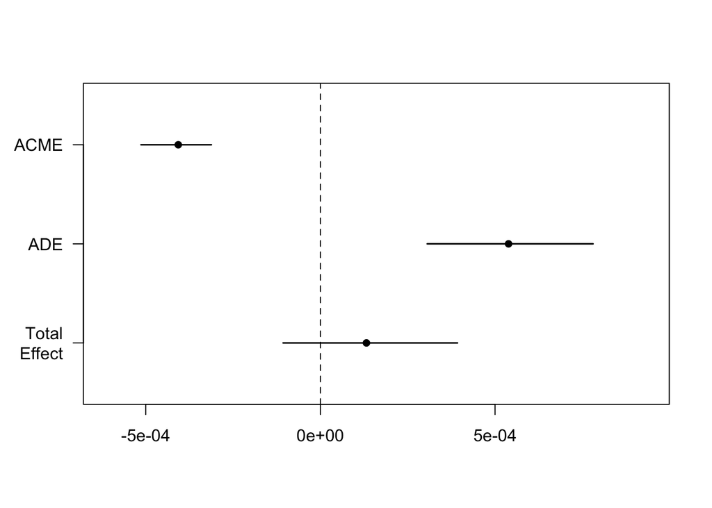

```r
plot(med_out)
```

## 8. Visualise child and partner rates across age — full sample

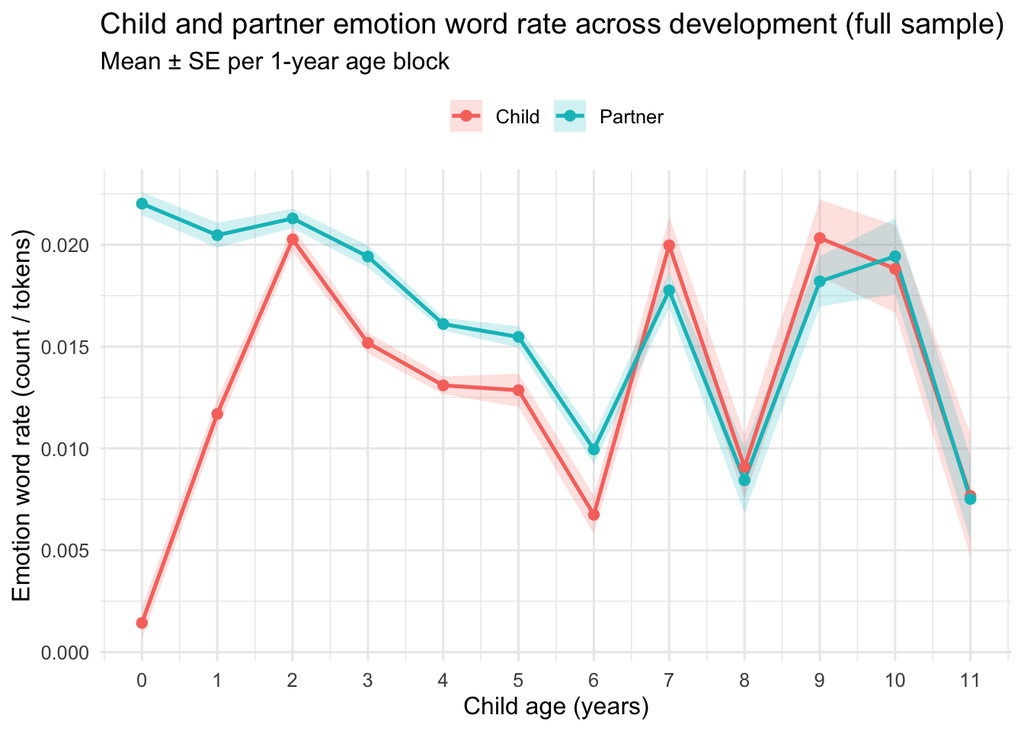

```r
rates_by_age <- transcript_all %>%
  mutate(age_block = floor(target_child_age_yrs)) %>%
  filter(age_block <= 11) %>%
  group_by(age_block) %>%
  summarise(
    n            = n(),
    child_mean   = mean(child_emo_rate,   na.rm = TRUE),
    child_se     = sd(child_emo_rate,     na.rm = TRUE) / sqrt(n()),
    partner_mean = mean(partner_emo_rate, na.rm = TRUE),
    partner_se   = sd(partner_emo_rate,   na.rm = TRUE) / sqrt(n()),
    .groups = "drop"
  ) %>%
  pivot_longer(c(child_mean, partner_mean),
               names_to = "speaker", values_to = "emo_rate") %>%
  mutate(
    se      = if_else(speaker == "child_mean", child_se, partner_se),
    speaker = if_else(speaker == "child_mean", "Child", "Partner")
  )

ggplot(rates_by_age, aes(x = age_block, y = emo_rate,
                          colour = speaker, fill = speaker)) +
  geom_ribbon(aes(ymin = emo_rate - se, ymax = emo_rate + se),
              alpha = 0.2, colour = NA) +
  geom_line(linewidth = 0.9) +
  geom_point(size = 2) +
  scale_x_continuous(breaks = 0:11) +
  labs(
    title    = "Child and partner emotion word rate across development (full sample)",
    subtitle = "Mean ± SE per 1-year age block",
    x = "Child age (years)", y = "Emotion word rate (count / tokens)",
    colour = NULL, fill = NULL
  ) +
  theme_minimal(base_size = 12) +
  theme(legend.position = "top")
```

# PART 2 — Partner-type comparison (dyadic transcripts only)

Only transcripts where the target child speaks to exactly **one** partner type are retained so that each transcript has an unambiguous partner category label.

## 9. Filter to dyadic transcripts

```r
dyadic_info <- utt %>%
  filter(role_category != "Target Child") %>%
  group_by(transcript_id) %>%
  summarise(
    n_partner_types = n_distinct(role_category),
    partner_type    = if_else(n_distinct(role_category) == 1,
                              first(role_category), NA_character_),
    .groups = "drop"
  )

dyadic_ids <- dyadic_info %>% filter(n_partner_types == 1)

cat("Total transcripts:            ", n_distinct(utt$transcript_id), "\n")
```

```
## Total transcripts:             7117
```

```r
cat("Dyadic (1 partner type):      ", nrow(dyadic_ids), "\n")
```

```
## Dyadic (1 partner type):       2584
```

```r
cat("Excluded (multiple partners): ",
    n_distinct(utt$transcript_id) - nrow(dyadic_ids), "\n\n")
```

```
## Excluded (multiple partners):  4533
```

```r
cat("Transcripts per partner category:\n")
```

```
## Transcripts per partner category:
```

```r
dyadic_ids %>% count(partner_type, name = "n") %>% arrange(desc(n)) %>% print()
```

```
## # A tibble: 5 × 2
##   partner_type     n
##   <chr>        <int>
## 1 Mother        1657
## 2 Other Adult    619
## 3 Father         199
## 4 Known Adult    105
## 5 Sibling          4
```

## 10. Aggregate dyadic transcripts

```r
utt_dyadic <- utt %>%
  filter(transcript_id %in% dyadic_ids$transcript_id) %>%
  left_join(dyadic_ids %>% dplyr::select(transcript_id, partner_type),
            by = "transcript_id")

speaker_summary_dyadic <- utt_dyadic %>%
  mutate(speaker_category = if_else(role_category == "Target Child",
                                    "child", "partner")) %>%
  group_by(transcript_id, speaker_category) %>%
  summarise(
    partner_type  = first(partner_type),
    total_tokens  = sum(num_tokens,    na.rm = TRUE),
    total_emotion = sum(emotion_count, na.rm = TRUE),
    n_utterances  = n(),
    .groups = "drop"
  ) %>%
  mutate(emo_rate = if_else(total_tokens > 0,
                             total_emotion / total_tokens, NA_real_))

transcript_dyadic <- speaker_summary_dyadic %>%
  pivot_wider(
    id_cols     = c(transcript_id, partner_type),
    names_from  = speaker_category,
    values_from = c(emo_rate, total_tokens, total_emotion, n_utterances)
  ) %>%
  rename(
    child_emo_rate   = emo_rate_child,
    partner_emo_rate = emo_rate_partner,
    child_tokens     = total_tokens_child,
    partner_tokens   = total_tokens_partner,
    child_emotion    = total_emotion_child,
    partner_emotion  = total_emotion_partner,
    child_utts       = n_utterances_child,
    partner_utts     = n_utterances_partner
  ) %>%
  left_join(age_lookup, by = "transcript_id") %>%
  mutate(target_child_age_yrs = target_child_age / 12) %>%
  filter(
    !is.na(child_emo_rate),
    !is.na(partner_emo_rate),
    !is.na(target_child_age_yrs),
    child_tokens   >= 10,
    partner_tokens >= 10
  ) %>%
  mutate(
    partner_type = factor(partner_type),
    partner_type = relevel(partner_type, ref = "Mother")
  )

# Drop partner types with fewer than 20 transcripts
keep_types <- transcript_dyadic %>%
  count(partner_type) %>%
  filter(n >= 20) %>%
  pull(partner_type)

transcript_dyadic <- transcript_dyadic %>% filter(partner_type %in% keep_types)

# Within / between decomposition
transcript_dyadic <- transcript_dyadic %>%
  group_by(target_child_id) %>%
  mutate(
    partner_emo_between = mean(partner_emo_rate, na.rm = TRUE),
    partner_emo_within  = partner_emo_rate - partner_emo_between
  ) %>%
  ungroup()

cat("Dyadic transcripts retained:", nrow(transcript_dyadic), "\n")
```

```
## Dyadic transcripts retained: 2143
```

```r
cat("Children:                   ", n_distinct(transcript_dyadic$target_child_id), "\n")
```

```
## Children:                    418
```

```r
cat("\nFinal n per partner type:\n")
```

```
##
## Final n per partner type:
```

```r
print(count(transcript_dyadic, partner_type))
```

```
## # A tibble: 4 × 2
##   partner_type     n
##   <fct>        <int>
## 1 Mother        1320
## 2 Father         176
## 3 Known Adult     71
## 4 Other Adult    576
```

## 11. Descriptives by partner type

```r
transcript_dyadic %>%
  group_by(partner_type) %>%
  summarise(
    n                = n(),
    age_mean         = round(mean(target_child_age_yrs), 2),
    child_emo_mean   = round(mean(child_emo_rate,   na.rm = TRUE), 4),
    child_emo_sd     = round(sd(child_emo_rate,     na.rm = TRUE), 4),
    partner_emo_mean = round(mean(partner_emo_rate, na.rm = TRUE), 4),
    partner_emo_sd   = round(sd(partner_emo_rate,   na.rm = TRUE), 4),
    .groups = "drop"
  ) %>%
  arrange(desc(n)) %>%
  print()
```

```
## # A tibble: 4 × 7
##   partner_type     n age_mean child_emo_mean child_emo_sd partner_emo_mean
##   <fct>        <int>    <dbl>          <dbl>        <dbl>            <dbl>
## 1 Mother        1320     2.87         0.0176       0.0244           0.0213
## 2 Other Adult    576     5.65         0.007        0.0077           0.0099
## 3 Father         176     2.75         0.0119       0.0116           0.0229
## 4 Known Adult     71     4.01         0.0195       0.0308           0.0176
## # ℹ 1 more variable: partner_emo_sd <dbl>
```

## 12. Does child emotion rate differ by partner type?

```r
m_partner_level <- lmer(
  child_emo_rate ~
    partner_type +
    ns(target_child_age_yrs, df = 3) +
    target_child_sex +
    (1 | target_child_id),
  data    = transcript_dyadic,
  REML    = TRUE,
  control = lmerControl(optimizer = "bobyqa")
)

summary(m_partner_level)
```

```
## Linear mixed model fit by REML. t-tests use Satterthwaite's method [
## lmerModLmerTest]
## Formula: child_emo_rate ~ partner_type + ns(target_child_age_yrs, df = 3) +
##     target_child_sex + (1 | target_child_id)
##    Data: transcript_dyadic
## Control: lmerControl(optimizer = "bobyqa")
##
## REML criterion at convergence: -10187.4
##
## Scaled residuals:
##     Min      1Q  Median      3Q     Max
## -3.1396 -0.4237 -0.1265  0.2477  6.4790
##
## Random effects:
##  Groups          Name        Variance  Std.Dev.
##  target_child_id (Intercept) 0.0002975 0.01725
##  Residual                    0.0002424 0.01557
## Number of obs: 1959, groups:  target_child_id, 402
##
## Fixed effects:
##                                     Estimate Std. Error         df t value
## (Intercept)                       -6.456e-04  2.910e-03  9.011e+02  -0.222
## partner_typeFather                -3.142e-03  3.320e-03  1.856e+03  -0.947
## partner_typeKnown Adult           -2.195e-03  1.564e-02  1.416e+03  -0.140
## partner_typeOther Adult           -3.518e-03  1.413e-03  1.874e+03  -2.489
## ns(target_child_age_yrs, df = 3)1 -3.205e-03  3.288e-03  1.889e+03  -0.975
## ns(target_child_age_yrs, df = 3)2  3.808e-02  6.259e-03  1.481e+03   6.084
## ns(target_child_age_yrs, df = 3)3  3.798e-03  4.646e-03  1.481e+03   0.817
## target_child_sexmale              -1.852e-04  2.130e-03  2.681e+02  -0.087
##                                   Pr(>|t|)
## (Intercept)                         0.8245
## partner_typeFather                  0.3440
## partner_typeKnown Adult             0.8884
## partner_typeOther Adult             0.0129 *
## ns(target_child_age_yrs, df = 3)1   0.3298
## ns(target_child_age_yrs, df = 3)2 1.49e-09 ***
## ns(target_child_age_yrs, df = 3)3   0.4139
## target_child_sexmale                0.9308
## ---
## Signif. codes:  0 '***' 0.001 '**' 0.01 '*' 0.05 '.' 0.1 ' ' 1
##
## Correlation of Fixed Effects:
##             (Intr) prtn_F prt_KA prt_OA n(___,d=3)1 n(___,d=3)2 n(___,d=3)3
## prtnr_typFt -0.002
## prtnr_typKA  0.014  0.000
## prtnr_typOA -0.057  0.036 -0.011
## n(___,d=3)1 -0.142 -0.021  0.031 -0.436
## n(___,d=3)2 -0.803 -0.013 -0.010 -0.129  0.154
## n(___,d=3)3 -0.346  0.005  0.009 -0.086 -0.138       0.657
## trgt_chld_s -0.395 -0.053  0.001  0.006 -0.002       0.040       0.059
```

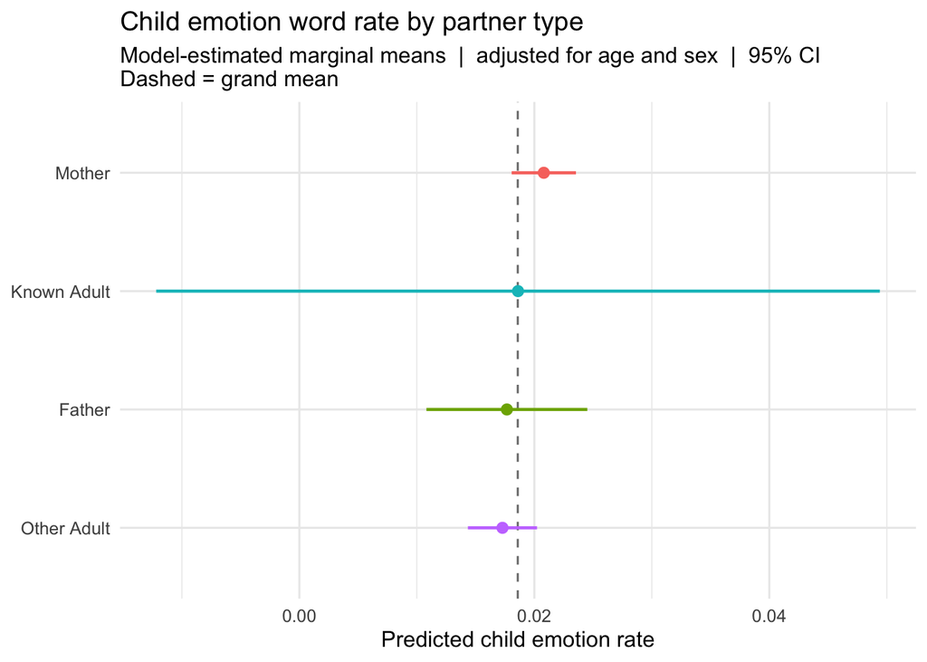

```r
# Estimated marginal means
emm_partner <- emmeans(m_partner_level, ~ partner_type) %>% as_tibble()

ggplot(emm_partner,
       aes(x = reorder(partner_type, emmean), y = emmean,
           colour = partner_type)) +
  geom_hline(yintercept = mean(emm_partner$emmean),
             linetype = "dashed", colour = "grey50") +
  geom_pointrange(aes(ymin = lower.CL, ymax = upper.CL),
                  linewidth = 0.8, fatten = 3) +
  coord_flip() +
  labs(
    title    = "Child emotion word rate by partner type",
    subtitle = "Model-estimated marginal means  |  adjusted for age and sex  |  95% CI\nDashed = grand mean",
    x = NULL, y = "Predicted child emotion rate"
  ) +
  theme_minimal(base_size = 12) +
  theme(legend.position = "none")
```

## 13. Does the partner → child responsiveness differ by partner type?

```r
m_partner_slope <- lmer(
  child_emo_rate ~
    partner_emo_within * partner_type +
    partner_emo_between +
    ns(target_child_age_yrs, df = 3) +
    target_child_sex +
    (1 + partner_emo_within | target_child_id),
  data    = transcript_dyadic,
  REML    = TRUE,
  control = lmerControl(optimizer = "bobyqa")
)
```

```
## fixed-effect model matrix is rank deficient so dropping 1 column / coefficient
## fixed-effect model matrix is rank deficient so dropping 1 column / coefficient
```

```r
summary(m_partner_slope)
```

```
## Linear mixed model fit by REML. t-tests use Satterthwaite's method [
## lmerModLmerTest]
## Formula:
## child_emo_rate ~ partner_emo_within * partner_type + partner_emo_between +
##     ns(target_child_age_yrs, df = 3) + target_child_sex + (1 +
##     partner_emo_within | target_child_id)
##    Data: transcript_dyadic
## Control: lmerControl(optimizer = "bobyqa")
##
## REML criterion at convergence: -10430
##
## Scaled residuals:
##     Min      1Q  Median      3Q     Max
## -3.5488 -0.4077 -0.1124  0.2376  6.8643
##
## Random effects:
##  Groups          Name               Variance  Std.Dev. Corr
##  target_child_id (Intercept)        0.0002312 0.01520
##                  partner_emo_within 0.1820254 0.42664  0.29
##  Residual                           0.0002100 0.01449
## Number of obs: 1959, groups:  target_child_id, 402
##
## Fixed effects:
##                                              Estimate Std. Error         df
## (Intercept)                                -1.489e-02  2.973e-03  6.947e+02
## partner_emo_within                          3.340e-01  7.859e-02  7.072e+01
## partner_typeFather                         -1.925e-03  3.306e-03  1.415e+03
## partner_typeKnown Adult                    -2.048e-04  1.456e-02  1.360e+03
## partner_typeOther Adult                    -8.312e-04  1.355e-03  1.845e+03
## partner_emo_between                         7.737e-01  7.056e-02  3.854e+02
## ns(target_child_age_yrs, df = 3)1          -2.148e-03  3.138e-03  1.834e+03
## ns(target_child_age_yrs, df = 3)2           3.588e-02  5.785e-03  1.403e+03
## ns(target_child_age_yrs, df = 3)3           8.562e-03  4.311e-03  1.416e+03
## target_child_sexmale                       -8.619e-04  1.907e-03  2.730e+02
## partner_emo_within:partner_typeFather       2.693e-02  2.063e-01  8.794e+01
## partner_emo_within:partner_typeOther Adult -2.533e-01  9.895e-02  1.072e+03
##                                            t value Pr(>|t|)
## (Intercept)                                 -5.009 6.96e-07 ***
## partner_emo_within                           4.250 6.41e-05 ***
## partner_typeFather                          -0.582   0.5605
```

[output cut: 24 more lines]

```
## prtnr__:_OA -0.024 -0.340    -0.002  0.006  0.007  0.027     0.071
##             n(___,d=3)2 n(___,d=3)3 trgt__ p__:_F
## prtnr_m_wth
## prtnr_typFt
## prtnr_typKA
## prtnr_typOA
## prtnr_m_btw
## n(___,d=3)1
## n(___,d=3)2
## n(___,d=3)3  0.647
## trgt_chld_s  0.041       0.056
## prtnr_m_:_F -0.011       0.002      -0.016
## prtnr__:_OA  0.027       0.025      -0.013  0.092
## fit warnings:
## fixed-effect model matrix is rank deficient so dropping 1 column / coefficient
```

```r
# Model comparison — does the interaction improve fit?
m_partner_slope_noint <- lmer(
  child_emo_rate ~
    partner_emo_within + partner_type +
    partner_emo_between +
    ns(target_child_age_yrs, df = 3) +
    target_child_sex +
    (1 + partner_emo_within | target_child_id),
  data    = transcript_dyadic,
  REML    = FALSE,
  control = lmerControl(optimizer = "bobyqa")
)

anova(m_partner_slope_noint, update(m_partner_slope, REML = FALSE))
```

```
## fixed-effect model matrix is rank deficient so dropping 1 column / coefficient
## fixed-effect model matrix is rank deficient so dropping 1 column / coefficient
```

```
## Data: transcript_dyadic
## Models:
## m_partner_slope_noint: child_emo_rate ~ partner_emo_within + partner_type + partner_emo_between + ns(target_child_age_yrs, df = 3) + target_child_sex + (1 + partner_emo_within | target_child_id)
## update(m_partner_slope, REML = FALSE): child_emo_rate ~ partner_emo_within * partner_type + partner_emo_between + ns(target_child_age_yrs, df = 3) + target_child_sex + (1 + partner_emo_within | target_child_id)
##                                       npar    AIC    BIC logLik -2*log(L)
## m_partner_slope_noint                   14 -10485 -10407 5256.6    -10513
## update(m_partner_slope, REML = FALSE)   16 -10488 -10398 5259.9    -10520
##                                        Chisq Df Pr(>Chisq)
## m_partner_slope_noint
## update(m_partner_slope, REML = FALSE) 6.6386  2    0.03618 *
## ---
## Signif. codes:  0 '***' 0.001 '**' 0.01 '*' 0.05 '.' 0.1 ' ' 1
```

## 14. Partner → child slopes per partner type

```r
slope_est <- emtrends(m_partner_slope,
                      var   = "partner_emo_within",
                      specs = ~ partner_type) %>%
  as_tibble() %>%
  arrange(desc(partner_emo_within.trend)) %>%
  mutate(sig = if_else(lower.CL > 0 | upper.CL < 0, "sig", "n.s."))

print(slope_est)
```

```
## # A tibble: 4 × 7
##   partner_type partner_emo_within.trend      SE    df lower.CL upper.CL sig
##   <fct>                           <dbl>   <dbl> <dbl>    <dbl>    <dbl> <chr>
## 1 Father                         0.361   0.207   74.3  -0.0514    0.773 n.s.
## 2 Mother                         0.334   0.0804  76.5   0.174     0.494 sig
## 3 Other Adult                    0.0807  0.105  301.   -0.125     0.286 n.s.
## 4 Known Adult                   NA      NA       NA    NA        NA     <NA>
```

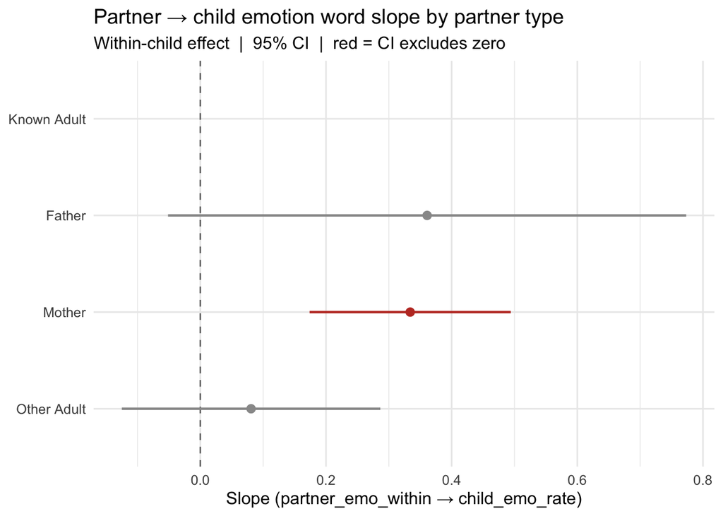

```r
ggplot(slope_est,
       aes(x = reorder(partner_type, partner_emo_within.trend),
           y = partner_emo_within.trend, colour = sig)) +
  geom_hline(yintercept = 0, linetype = "dashed", colour = "grey50") +
  geom_pointrange(aes(ymin = lower.CL, ymax = upper.CL),
                  linewidth = 0.8, fatten = 3) +
  scale_colour_manual(values = c("sig" = "#c0392b", "n.s." = "grey60")) +
  coord_flip() +
  labs(
    title    = "Partner → child emotion word slope by partner type",
    subtitle = "Within-child effect  |  95% CI  |  red = CI excludes zero",
    x = NULL, y = "Slope (partner_emo_within → child_emo_rate)"
  ) +
  theme_minimal(base_size = 12) +
  theme(legend.position = "none")
```

## 15. Save

```r
saveRDS(transcript_all,     here("01Data", "02Derived", "additional_full_sample.rds"))
saveRDS(transcript_dyadic,  here("01Data", "02Derived", "additional_dyadic.rds"))
saveRDS(m_mod,              here("01Data", "02Derived", "additional_mod_model.rds"))
saveRDS(m_partner_level,    here("01Data", "02Derived", "additional_partner_level_model.rds"))
saveRDS(m_partner_slope,    here("01Data", "02Derived", "additional_partner_slope_model.rds"))
```